# Red wine quality EDA

Taef al khales

## 1. The Data

- *fixed acidity*: most acids involved with wine or fixed or nonvolatile.
- *volatile acidity*:the amount of acetic acid in wine, which at too high of levels can lead to an unpleasant, vinegar taste
- citric acid:found in small quantities, citric acid can add ‘freshness’ and flavor to wines
- *residual sugar*: the amount of sugar remaining after fermentation stops, it’s rare to find wines with less than 1 gram/liter and wines with greater than 45 grams/liter are considered sweet
- *chlorides*: the amount of salt in the wine
- *free sulfur dioxide* : the free form of SO2 exists in equilibrium between molecular SO2 (as a dissolved gas) and bisulfite ion
- *total sulfur dioxide*: amount of free and bound forms of S02; in low concentrations
- *density*: the density of water is close to that of water depending on the percent alcohol and sugar content
- *pH*:describes how acidic or basic a wine is on a scale from 0 (very acidic) to 14 (very basic); most wines are between 3-4 on the pH scale
- *sulphates*: a wine additive which can contribute to sulfur dioxide gas (S02) levels, wich acts as an antimicrobial and antioxidant
- *alcohol*:the percent alcohol content of the wine
- *quality* (score between 0 and 10)

## 2. EDA

### 2.1 First look at the data

| fixed acidity | volatile acidity | citric acid | residual sugar | chlorides | free sulfur dioxide | total sulfur dioxide | density | pH | sulphates | alcohol | quality |
| --- | --- | --- | --- | --- | --- | --- | --- | --- | --- | --- | --- |
| 7.4 | 0.70 | 0.00 | 1.9 | 0.076 | 11 | 34 | 0.9978 | 3.51 | 0.56 | 9.4 | 5 |
| 7.8 | 0.88 | 0.00 | 2.6 | 0.098 | 25 | 67 | 0.9968 | 3.20 | 0.68 | 9.8 | 5 |
| 7.8 | 0.76 | 0.04 | 2.3 | 0.092 | 15 | 54 | 0.9970 | 3.26 | 0.65 | 9.8 | 5 |
| 11.2 | 0.28 | 0.56 | 1.9 | 0.075 | 17 | 60 | 0.9980 | 3.16 | 0.58 | 9.8 | 6 |
| 7.4 | 0.70 | 0.00 | 1.9 | 0.076 | 11 | 34 | 0.9978 | 3.51 | 0.56 | 9.4 | 5 |
| 7.4 | 0.66 | 0.00 | 1.8 | 0.075 | 13 | 40 | 0.9978 | 3.51 | 0.56 | 9.4 | 5 |

### 2.2 Tidy up the columns names

Now the names are seprated with (_) instead of a space.

| fixed_acidity | volatile_acidity | citric_acid | residual_sugar | chlorides | free_sulfur_dioxide | total_sulfur_dioxide | density | p_h | sulphates | alcohol | quality |
| --- | --- | --- | --- | --- | --- | --- | --- | --- | --- | --- | --- |
| 7.4 | 0.7 | 0 | 1.9 | 0.076 | 11 | 34 | 0.9978 | 3.51 | 0.56 | 9.4 | 5 |
| 7.8 | 0.88 | 0 | 2.6 | 0.098 | 25 | 67 | 0.9968 | 3.2 | 0.68 | 9.8 | 5 |
| 7.8 | 0.76 | 0.04 | 2.3 | 0.092 | 15 | 54 | 0.997 | 3.26 | 0.65 | 9.8 | 5 |
| 11.2 | 0.28 | 0.56 | 1.9 | 0.075 | 17 | 60 | 0.998 | 3.16 | 0.58 | 9.8 | 6 |
| 7.4 | 0.7 | 0 | 1.9 | 0.076 | 11 | 34 | 0.9978 | 3.51 | 0.56 | 9.4 | 5 |
| 7.4 | 0.66 | 0 | 1.8 | 0.075 | 13 | 40 | 0.9978 | 3.51 | 0.56 | 9.4 | 5 |
| 7.9 | 0.6 | 0.06 | 1.6 | 0.069 | 15 | 59 | 0.9964 | 3.3 | 0.46 | 9.4 | 5 |
| 7.3 | 0.65 | 0 | 1.2 | 0.065 | 15 | 21 | 0.9946 | 3.39 | 0.47 | 10 | 7 |
| 7.8 | 0.58 | 0.02 | 2 | 0.073 | 9 | 18 | 0.9968 | 3.36 | 0.57 | 9.5 | 7 |
| 7.5 | 0.5 | 0.36 | 6.1 | 0.071 | 17 | 102 | 0.9978 | 3.35 | 0.8 | 10.5 | 5 |

[output cut: 1589 more lines]

### 2.3 Summary statistics

Skim is a very nice package for summary statistics [Skim](https://docs.ropensci.org/skimr/reference/skim.html).

```r
skim(wine_clean)
```

Data summary

| Name | wine_clean |
| --- | --- |
| Number of rows | 1599 |
| Number of columns | 12 |
| _______________________ |  |
| Column type frequency: |  |
| numeric | 12 |
| ________________________ |  |
| Group variables | None |

**Variable type: numeric**

| skim_variable | n_missing | complete_rate | mean | sd | p0 | p25 | p50 | p75 | p100 | hist |
| --- | --- | --- | --- | --- | --- | --- | --- | --- | --- | --- |
| fixed_acidity | 0 | 1 | 8.32 | 1.74 | 4.60 | 7.10 | 7.90 | 9.20 | 15.90 | ▂▇▂▁▁ |
| volatile_acidity | 0 | 1 | 0.53 | 0.18 | 0.12 | 0.39 | 0.52 | 0.64 | 1.58 | ▅▇▂▁▁ |
| citric_acid | 0 | 1 | 0.27 | 0.19 | 0.00 | 0.09 | 0.26 | 0.42 | 1.00 | ▇▆▅▁▁ |
| residual_sugar | 0 | 1 | 2.54 | 1.41 | 0.90 | 1.90 | 2.20 | 2.60 | 15.50 | ▇▁▁▁▁ |
| chlorides | 0 | 1 | 0.09 | 0.05 | 0.01 | 0.07 | 0.08 | 0.09 | 0.61 | ▇▁▁▁▁ |
| free_sulfur_dioxide | 0 | 1 | 15.87 | 10.46 | 1.00 | 7.00 | 14.00 | 21.00 | 72.00 | ▇▅▁▁▁ |
| total_sulfur_dioxide | 0 | 1 | 46.47 | 32.90 | 6.00 | 22.00 | 38.00 | 62.00 | 289.00 | ▇▂▁▁▁ |
| density | 0 | 1 | 1.00 | 0.00 | 0.99 | 1.00 | 1.00 | 1.00 | 1.00 | ▁▃▇▂▁ |
| p_h | 0 | 1 | 3.31 | 0.15 | 2.74 | 3.21 | 3.31 | 3.40 | 4.01 | ▁▅▇▂▁ |
| sulphates | 0 | 1 | 0.66 | 0.17 | 0.33 | 0.55 | 0.62 | 0.73 | 2.00 | ▇▅▁▁▁ |
| alcohol | 0 | 1 | 10.42 | 1.07 | 8.40 | 9.50 | 10.20 | 11.10 | 14.90 | ▇▇▃▁▁ |
| quality | 0 | 1 | 5.64 | 0.81 | 3.00 | 5.00 | 6.00 | 6.00 | 8.00 | ▁▇▇▂▁ |

We can see the following things:

1. all columns are numeric
2. no missing values
3. it is not a big dataset

### 2.4 Univariate

### 2.4.1 Quality Distribution

It appears that is this sample dataset, the most frequent wine quality are 5 and 6.

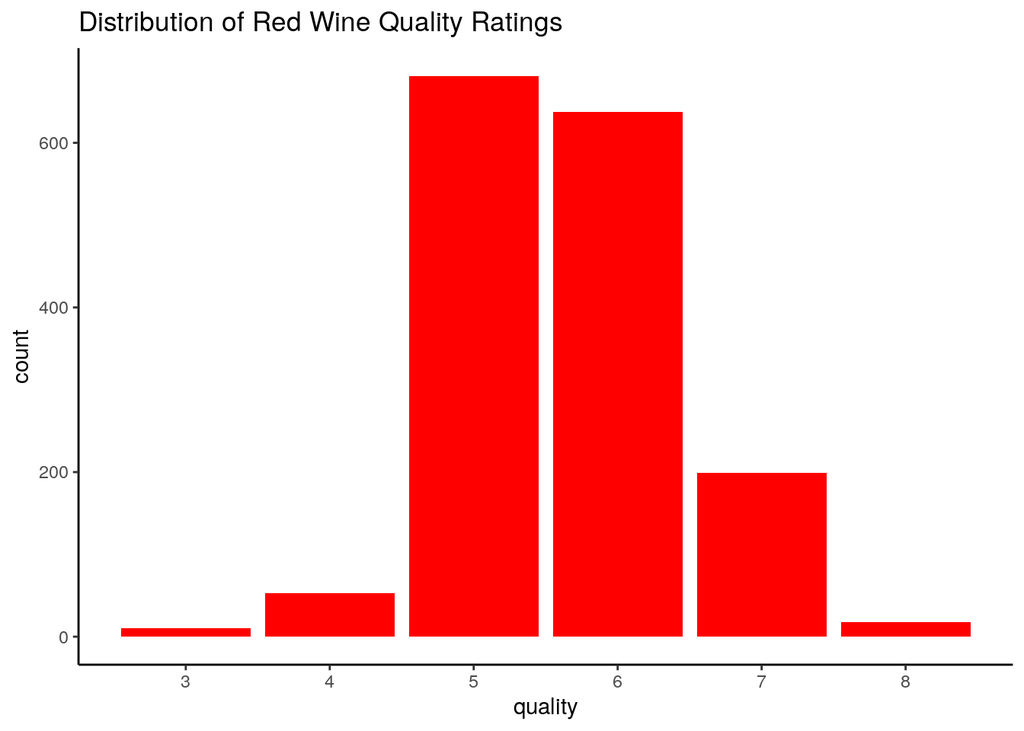

### 2.4.2 PH Distribution (boxplot)

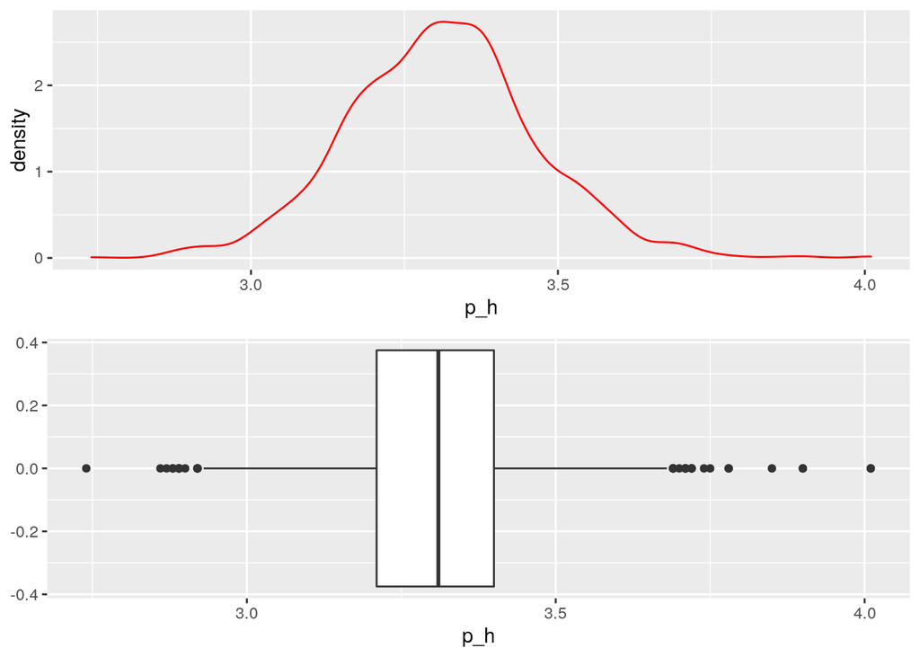

### 2.4.3 All data Distribution

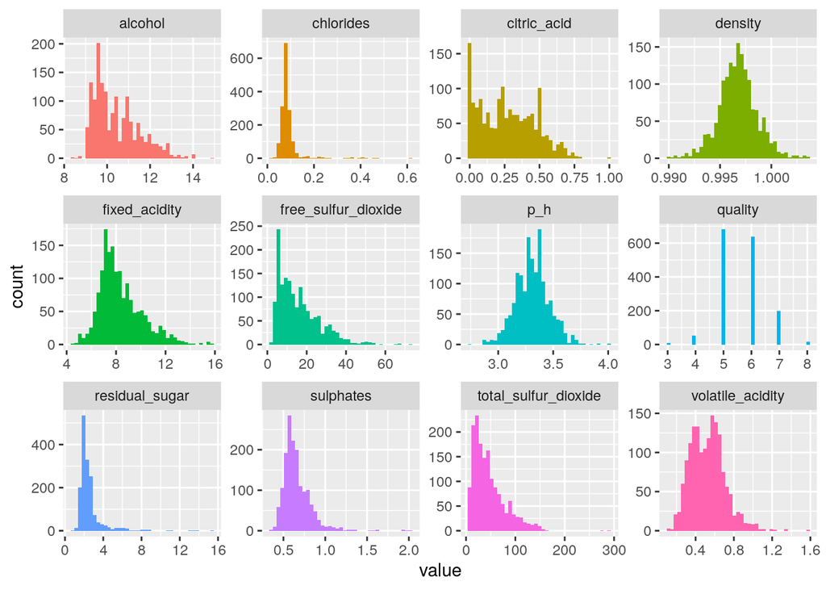

### 2.4.2 Alcohol Distribution (boxplot)

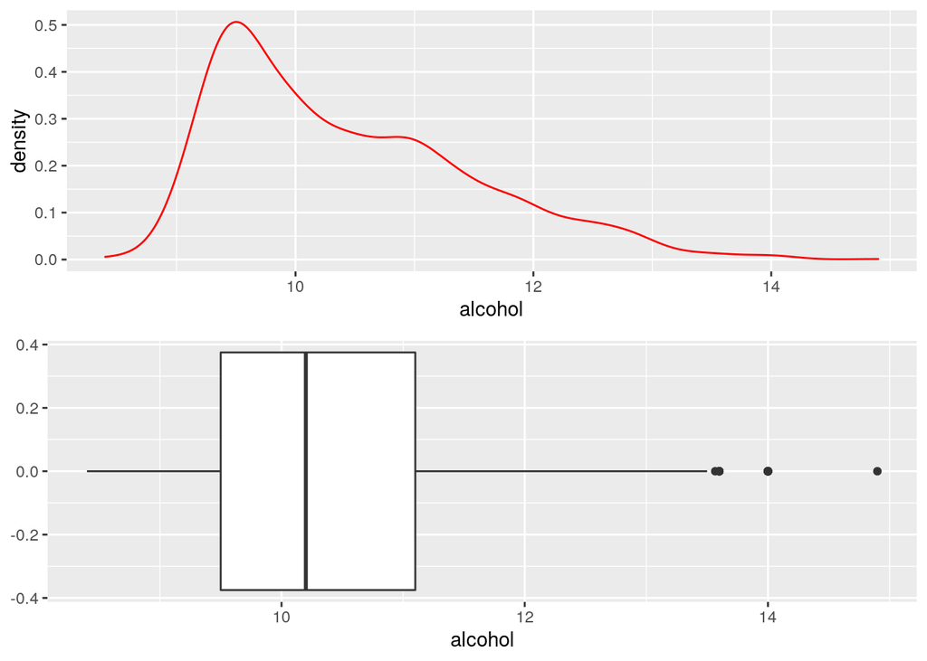

### 2.5 Bivariate

### 2.5.1 GGPair graph (group by quality)

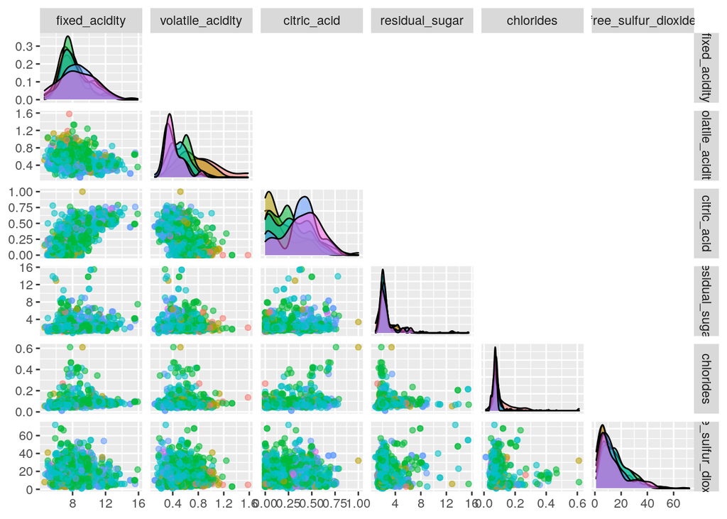

```r
wine_ggpair <- wine_clean
wine_ggpair$quality <- as.factor(wine_ggpair$quality)
ggpairs(wine_ggpair,columns = 1:6,aes(colour = quality, alpha = 0.4), upper=list(continuous = "blank"))
```

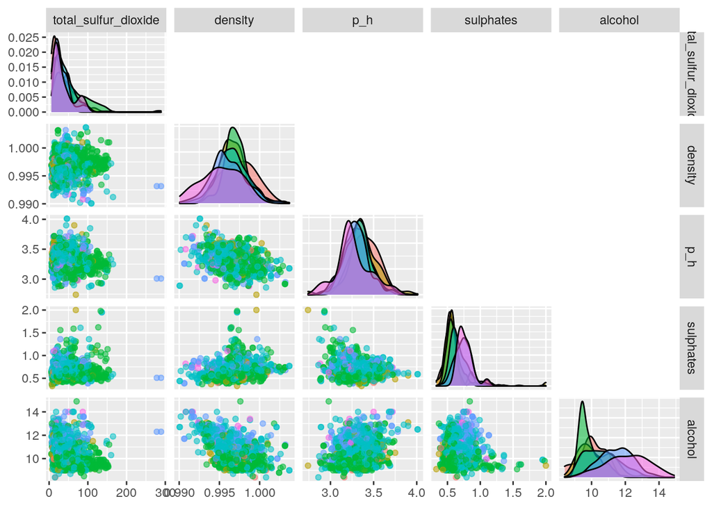

```r
wine_ggpair2 <- wine_clean
wine_ggpair2$quality <- as.factor(wine_ggpair2$quality)
ggpairs(wine_ggpair2,columns = 7:11,aes(colour = quality, alpha = 0.4), upper=list(continuous = "blank"))
```

### 2.5.2 Correlation (heatmap)

[output not shown]

[output cut: 76 more lines]

[output not shown]

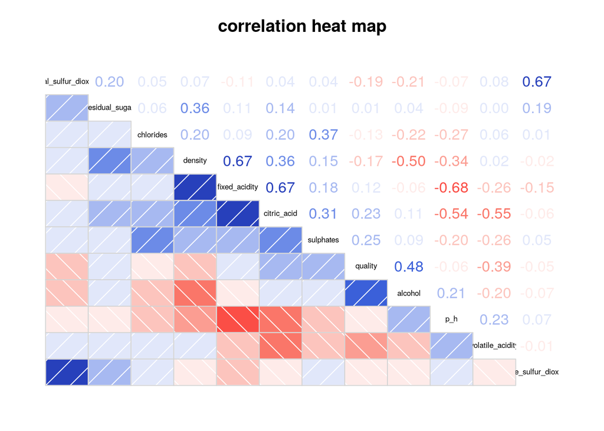

### 2.6 Mean values grouped by the quality

```r
wine_df <- wine_clean %>% group_by(quality) %>% summarise(across(everything(), mean))
wine_df <- signif(wine_df, digits = 3)
reactable(wine_df)
```

| quality | fixed_acidity | volatile_acidity | citric_acid | residual_sugar | chlorides | free_sulfur_dioxide | total_sulfur_dioxide | density | p_h | sulphates | alcohol |
| --- | --- | --- | --- | --- | --- | --- | --- | --- | --- | --- | --- |
| 3 | 8.36 | 0.884 | 0.171 | 2.64 | 0.122 | 11 | 24.9 | 0.997 | 3.4 | 0.57 | 9.96 |
| 4 | 7.78 | 0.694 | 0.174 | 2.69 | 0.0907 | 12.3 | 36.2 | 0.997 | 3.38 | 0.596 | 10.3 |
| 5 | 8.17 | 0.577 | 0.244 | 2.53 | 0.0927 | 17 | 56.5 | 0.997 | 3.3 | 0.621 | 9.9 |
| 6 | 8.35 | 0.497 | 0.274 | 2.48 | 0.085 | 15.7 | 40.9 | 0.997 | 3.32 | 0.675 | 10.6 |
| 7 | 8.87 | 0.404 | 0.375 | 2.72 | 0.0766 | 14 | 35 | 0.996 | 3.29 | 0.741 | 11.5 |
| 8 | 8.57 | 0.423 | 0.391 | 2.58 | 0.0684 | 13.3 | 33.4 | 0.995 | 3.27 | 0.768 | 12.1 |